# АнДан_Шляхтина_4

```r
library(tidyverse)
```

```r
library(ggplot2)
```

```r
library(dplyr)
```

```r
# Шляхтина Людмила
```

1. Универсальные лингвические иерархии: порядок прилагательных в новогреческом языке (стандартный и кипрский диалекты) Данные (социолингвистическая анкета и результаты эксперимента в одном файле) взяты, с адаптацией, из исследования: Leivada, Evelina; Westergaard, Marit, 2019, Universal linguistic hierarchies are not innately wired. PeerJ, v.7.

Источник данных: репозиторий TROLLing: Leivada, Evelina; Westergaard, Marit, 2019, “Replication Data for: Universal linguistic hierarchies are not innately wired”, https://doi.org/10.18710/NTLLUF, DataverseNO, V1

определяется семантическим классом прилагательного (например, прилагательное «цвета» ближе к существительному, чем прилагательное «размера»).

Данные Загрузите данные из файла в переменную mono, переведя строковые данные в факторы. В переменной mono_socio сохраните данные социолингвистической анкеты. В переменной mono оставьте только данные самого эксперимента. Переименуйте заголовки в последней таблице в следующие: “ParticipantID”, “QuestionType”, “NQuestions”, “Likert”, “RT”.

```r
mono <- read.csv("https://raw.githubusercontent.com/olesar/2025dav4compling/refs/heads/main/data/greek-word-order-mono-acceptability-coded-rt.txt", sep=";", stringsAsFactors = TRUE)
head(mono)
```

A data.frame: 6 × 6

|  | ParticipantID <fct> | TypeOfQuestion <fct> | TypeOfStimuli <fct> | WordOrder <fct> | ResponseAcceptabilityJudgement <fct> | RT <int> |
| --- | --- | --- | --- | --- | --- | --- |
| 1 | 00e0b159cf5b9abcc73b92506d8b1c38 | AcceptabilityJudgement | Size-Nationality | Congruent | Correct | 1591 |
| 2 | 00e0b159cf5b9abcc73b92506d8b1c38 | AcceptabilityJudgement | Size-Nationality | Incongruent | Correct | 5504 |
| 3 | 00e0b159cf5b9abcc73b92506d8b1c38 | AcceptabilityJudgement | Size-Nationality | Congruent | Correct | 1333 |
| 4 | 00e0b159cf5b9abcc73b92506d8b1c38 | AcceptabilityJudgement | Size-Nationality | Incongruent | Correct | 1543 |
| 5 | 00e0b159cf5b9abcc73b92506d8b1c38 | AcceptabilityJudgement | Size-Nationality | Congruent | Correct | 1815 |
| 6 | 00e0b159cf5b9abcc73b92506d8b1c38 | AcceptabilityJudgement | Size-Nationality | Incongruent | Correct | 3059 |

```r
mono_socio <- read.csv("https://raw.githubusercontent.com/olesar/2025dav4compling/refs/heads/main/data/greek-word-order-mono_socio.txt", sep = ";", header = TRUE)
head(mono_socio)
```

A data.frame: 6 × 4

|  | ParticipantID <chr> | TypeOfQuestion <chr> | QuestionCategory <chr> | Responce <chr> |
| --- | --- | --- | --- | --- |
| 1 | 2bc93481d25426f259a0f1a3d5d3e824 | Form | age | 58 |
| 2 | 2bc93481d25426f259a0f1a3d5d3e824 | Form | country1 | Nicosia |
| 3 | 2bc93481d25426f259a0f1a3d5d3e824 | Form | country2 | Kaimakli,Nicosia |
| 4 | 2bc93481d25426f259a0f1a3d5d3e824 | Form | education | College |
| 5 | 2bc93481d25426f259a0f1a3d5d3e824 | Form | handedness | right |
| 6 | 2bc93481d25426f259a0f1a3d5d3e824 | Form | sex | female |

Описание данных 1.1 Взглянем на данные mono_socio, чтобы ответить на следующие вопросы о социолингвистических характеристиках испытуемых:

Сколько участников указано в датафрейме?

Сколько из них женщин и мужчин?

Какие уровни образования указаны в датафрейме?

Сколько участников каждого уровня образования?

Сколько леворуких и праворуких участников?

Напишите код, представляющий ответы на эти вопросы в виде одной или нескольких таблиц. Используйте функции из пакета tidyverse: filter, group_by, count and distinct. (Еще один способ - использовать pivot_wider.)

```r
mono_socio_wide <- mono_socio %>% pivot_wider(names_from = QuestionCategory, values_from = Responce)
mono_socio_wide
```

A tibble: 30 × 8

| ParticipantID <chr> | TypeOfQuestion <chr> | age <chr> | country1 <chr> | country2 <chr> | education <chr> | handedness <chr> | sex <chr> |
| --- | --- | --- | --- | --- | --- | --- | --- |
| 2bc93481d25426f259a0f1a3d5d3e824 | Form | 58 | Nicosia | Kaimakli,Nicosia | College | right | female |
| 4b4c9debd4aedeb1fd3dfc9f1cab3b0b | Form | 24 | Nicosia | Nicosia | UniversityDegree | right | male |
| 5cfee92572d81db494f8036861d00c3d | Form | 33 | Nicosia | Nicosia | Postgraduate | right | female |
| 6a0bfef2c1607be61fa9879d30514cb2 | Form | 36 | Paphos | Nicosia | Postgraduate | right | male |
| 9c334b8c45452362a37cb790b05cff6d | Form | 23 | Limassol | Limassol | Postgraduate | right | female |
| 9eed449d848443290afdb9aca7ac7b21 | Form | 27 | Limassol,Cyprus | Limassol | UniversityDegree | right | female |
| 21dd0d72f74143f083e08841080c40c9 | Form | 46 | Nicosia | Moscow | Postgraduate | right | male |
| 25c1b946d47b93d059a2232013c51780 | Form | 34 | Limassol | Limassol | UniversityDegree | right | male |
| 79b886b6ef0a5213abc3cc5905b8b237 | Form | 32 | Nicosia | Nicosia | Postgraduate | right | female |
| 85b0e3c5d7dcaf0e1faa81dfe283b826 | Form | 24 | Nicosia | Nicosia | UniversityDegree | right | male |
| 0118ad6bcd31f187154c2ed1344cd57b | Form | 28 | Larnaca | Paphos | Postgraduate | right | male |
| 492e07754c9ad10c86222a33da47dc8b | Form | 28 | Cyprus | Cyprus | UniversityDegree | right | female |
| 607ba9a52e718bc60069c8fee9335b1f | Form | 31 | 1986 | Paphos,Cyprus | UniversityDegree | right | male |
| 853a6abae4c2f81889073dbf90c5c57b | Form | 19 | Nicosia | Nicosia | UniversityDegree | right | female |
| 944d59c9102fd8ce1d8172f9f4f784c1 | Form | 21 | Limassol,Cyprus | Limassol,Cyprus | College | right | female |
| 09251c0cb8fa8808513ba5beb497f569 | Form | 20 | Nicosia | Nicosia | UniversityDegree | right | female |
| 9542bc1c6a746283f1f7d9b1ee824a76 | Form | 29 | Limassol | Limassol | Postgraduate | right | female |
| 10641e1b505dda0cb82be1a8e1637c37 | Form | 29 | Nicosia,Cyprus | Nicosia,Cyprus | Postgraduate | right | female |
| 324340a79c0baf5a321d1933c517fdae | Form | 55 | Famagusta,Cyprus | Sotira,Cyprus | College | right | female |
| 80163577409836e099ebe789576d7a32 | Form | 29 | Limassol | Italia | UniversityDegree | right | female |
| a0872883e3c3635e9b535cd0173851f2 | Form | 67 | Lapethos,Cyprus | Greece | UniversityDegree | right | male |
| ac3d495977ee5b80cc3c0b49ea7db79a | Form | 26 | Nicosia | Florence | PhDongoing | right | male |
| ad58d2a1137448df8a86f151736ff336 | Form | 40 | Nicosia | Nicosia | UniversityDegree | right | female |
| b948590b02bd69d4a3fc9629b1f6062a | Form | 33 | Limassol | Limassol | Postgraduate | right | female |
| e7fd8db672dc8cef14d83739e2af6ea6 | Form | 28 | Nicosia | Nicosia | Postgraduate | right | female |
| ec041d028e48446856761f8d472c56e2 | Form | 35 | Nicosia | Nicosia | Postgraduate | right | male |
| ed33e57d048d12d246298f2e0e4192d6 | Form | 26 | Nicosia | Nicosia | Postgraduate | left | female |
| f5a9e1dafe1ce0ed8cfa4f2d1af80049 | Form | 30 | Nicosia | Nicosia | Postgraduate | left | male |
| f08c7d3d0b0177bc1d6858ebd43a6fba | Form | 20 | Larnaca,Cyprus | Heidelberg,Germany | UniversityDegree | right | female |
| f59baae2e06fd5964a604c13b3cf48dd | Form | 29 | Nicosia | Nicosia | Postgraduate | right | female |

```r
# Количество участников
nrow(mono_socio_wide)
```

30

```r
# Статистика по полу. Женщин 63%.
mono_socio_wide %>% group_by(sex) %>% count()
```

A grouped_df: 2 × 2

| sex <chr> | n <int> |
| --- | --- |
| female | 19 |
| male | 11 |

```r
# Какие представлены уровни образования
mono_socio_wide %>% distinct(education)
```

A tibble: 4 × 1

| education <chr> |
| --- |
| College |
| UniversityDegree |
| Postgraduate |
| PhDongoing |

```r
# Статистика по уровню образования. Подавляющее большинство получило высшее образование.
mono_socio_wide %>% group_by(education) %>% count()
```

A grouped_df: 4 × 2

| education <chr> | n <int> |
| --- | --- |
| College | 3 |
| PhDongoing | 1 |
| Postgraduate | 14 |
| UniversityDegree | 12 |

```r
# Доминирующая рука. Подавляющее большинство участников эксперимента - правши.
mono_socio_wide %>% group_by(handedness) %>% count()
```

A grouped_df: 2 × 2

| handedness <chr> | n <int> |
| --- | --- |
| left | 2 |
| right | 28 |

1.2 Сравните полученную информацию с данными из таблицы 1 в статье. Можно ли сказать, что данные, которые вы загрузили по ссылке, позволяют воспроизвести результаты этого исследования?

```r
# Пол: по ссылке женщин 63%, по статье 52%.
# Уровень образования: в статье два вида (школьное и высшее), по ссылке четыре. Если объединить PhDongoing, Postgraduate и UniversityDegree, то по статье школьное образование у 10%, по статье у 12%.
# Доминирующая рука: в статье левшей 10%, по ссылке левшей 6%.
```

```r
# В статье участников было больше примерно в 4.5 раз, данные разнятся, но не критически. Полностью воспроизвести результаты исследования, таким образом, у нас не получится.
# При этом данные полностью совпадают с таблицей 2 в статье.
```

1.3 Постройте график плотности, который показывает распределение RT в эксперименте в целом (для всех участников и условий. Отобразите красным пунктиром линию, показывающую среднее значение RT.

```r
# Вычисляем среднее RT
mean_rt <- mean(mono$RT)
```

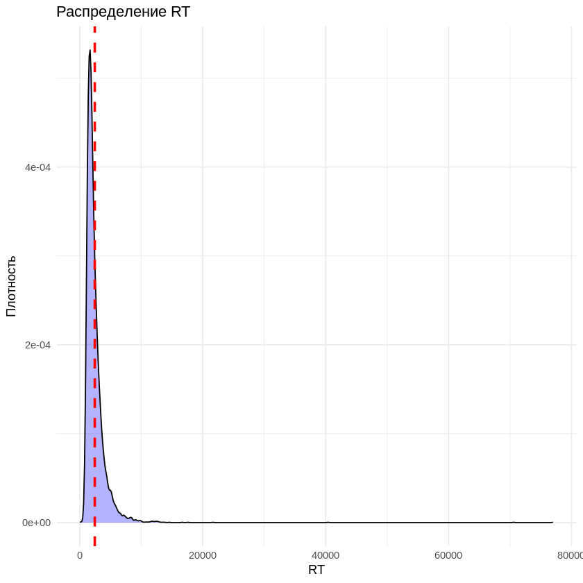

```r
ggplot(mono, aes(x = RT)) +
  geom_density(fill = "blue", alpha = 0.3) +
  geom_vline(xintercept = mean_rt, linetype = "dashed", color = "red", linewidth = 1) +
  labs(title = "Распределение RT",
       x = "RT",
       y = "Плотность") +
  theme_minimal()
```

1.4 Верно ли, что данные времени реакции нормально распределены? Есть ли в распределении длинные левые или правые хвосты??

```r
# Распределение напоминает колокол нормального распределения, но линия RT проходит не ровно по центру, а правый хвост слишком длинный.
# График не симметричный, так что нельзя сказать, что распределение нормальное.
```

1.5 Преобразуйте данные с помощью функциии логарифма (RTlog = log10(RT)).

```r
mono$RTlog = log10(mono$RT)
```

1.6 Создайте график, похожий на 1.3, но показывающий логарифимированные значения RT.

```r
# Вычисляем среднее RT
mean_log_rt <- mean(mono$RTlog)
```

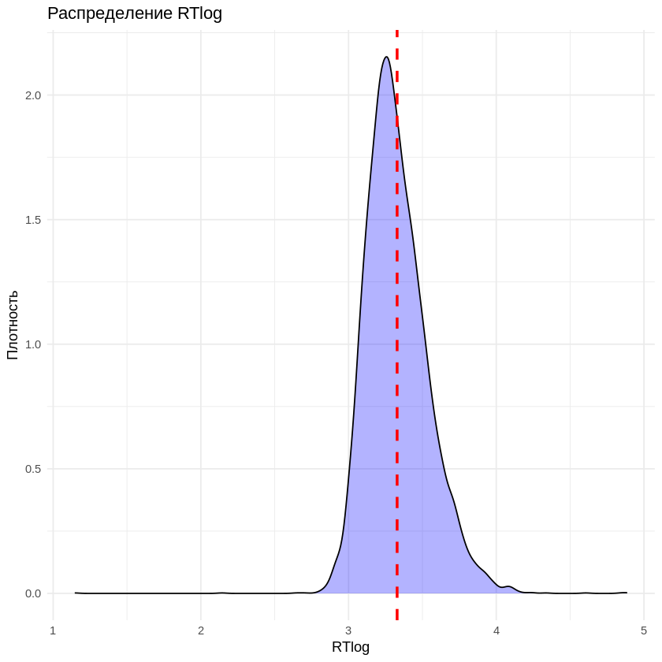

```r
ggplot(mono, aes(x = RTlog)) +
  geom_density(fill = "blue", alpha = 0.3) +
  geom_vline(xintercept = mean_log_rt, linetype = "dashed", color = "red", linewidth = 1) +
  labs(title = "Распределение RTlog",
       x = "RTlog",
       y = "Плотность") +
  theme_minimal()
# Этот график выглядит уже лучше, чем предыдущий, хотя всё равно наблюдается асимметрия и слишком длинные правые хвосты.
```

1.7 Отфильтруйте выбросы:

- автоматические ответы, время реакции на которые меньше 600 ms (будем полагать, что кнопка была нажата слишком быстро, еще до того, как у участника было достаточно времени рассмотреть показанный ему стимул и принять решение);
- ответы, в которых RTlog отличается от среднего значения RTlog более, чем на 3 стандартных отклонения (SD);
- филлеры (как приемлемые, так и неприемлемые). Сохраните очищенные от выбросов данные в переменную mono1.

```r
# Оставляем только те ответы, где время реакции больше 600.
mono1 <- mono %>% filter(RT >= 600)
```

```r
# Оставляем только те ответы, где RTlog отличается от среднего менее чем на 3 SD.
mean_rtlog <- mean(mono1$RTlog)  # Считаем среднее RTlog.
sd_rtlog <- sd(mono1$RTlog)      # Считаем стандартное отклонение RTlog.
mono1 <- mono1 %>% filter(abs(RTlog - mean_rtlog) <= 3 * sd_rtlog)
```

```r
# Удаляем филлеры.
mono1 <- mono1 %>%
  filter(!TypeOfStimuli %in% c("FillerUnacceptable", "FillerAcceptable"))
mono1
```

A data.frame: 2487 × 7

| ParticipantID <fct> | TypeOfQuestion <fct> | TypeOfStimuli <fct> | WordOrder <fct> | ResponseAcceptabilityJudgement <fct> | RT <int> | RTlog <dbl> |
| --- | --- | --- | --- | --- | --- | --- |
| 00e0b159cf5b9abcc73b92506d8b1c38 | AcceptabilityJudgement | Size-Nationality | Congruent | Correct | 1591 | 3.201670 |
| 00e0b159cf5b9abcc73b92506d8b1c38 | AcceptabilityJudgement | Size-Nationality | Incongruent | Correct | 5504 | 3.740678 |
| 00e0b159cf5b9abcc73b92506d8b1c38 | AcceptabilityJudgement | Size-Nationality | Congruent | Correct | 1333 | 3.124830 |
| 00e0b159cf5b9abcc73b92506d8b1c38 | AcceptabilityJudgement | Size-Nationality | Incongruent | Correct | 1543 | 3.188366 |
| 00e0b159cf5b9abcc73b92506d8b1c38 | AcceptabilityJudgement | Size-Nationality | Congruent | Correct | 1815 | 3.258877 |
| 00e0b159cf5b9abcc73b92506d8b1c38 | AcceptabilityJudgement | Size-Nationality | Incongruent | Correct | 3059 | 3.485579 |
| 00e0b159cf5b9abcc73b92506d8b1c38 | AcceptabilityJudgement | Shape-Color | Congruent | Correct | 1700 | 3.230449 |
| 00e0b159cf5b9abcc73b92506d8b1c38 | AcceptabilityJudgement | Shape-Color | Incongruent | Correct | 2745 | 3.438542 |
| 00e0b159cf5b9abcc73b92506d8b1c38 | AcceptabilityJudgement | Shape-Color | Congruent | Correct | 3237 | 3.510143 |
| 00e0b159cf5b9abcc73b92506d8b1c38 | AcceptabilityJudgement | Shape-Color | Incongruent | Correct | 2911 | 3.464042 |
| 00e0b159cf5b9abcc73b92506d8b1c38 | AcceptabilityJudgement | Shape-Color | Congruent | Correct | 1878 | 3.273696 |
| 00e0b159cf5b9abcc73b92506d8b1c38 | AcceptabilityJudgement | Shape-Color | Incongruent | Correct | 3796 | 3.579326 |
| 00e0b159cf5b9abcc73b92506d8b1c38 | AcceptabilityJudgement | SubjectiveComment-Material | Congruent | Wrong | 1168 | 3.067443 |
| 00e0b159cf5b9abcc73b92506d8b1c38 | AcceptabilityJudgement | SubjectiveComment-Material | Incongruent | Correct | 2429 | 3.385428 |
| 00e0b159cf5b9abcc73b92506d8b1c38 | AcceptabilityJudgement | SubjectiveComment-Material | Congruent | Correct | 2189 | 3.340246 |
| 00e0b159cf5b9abcc73b92506d8b1c38 | AcceptabilityJudgement | SubjectiveComment-Material | Incongruent | Neither | 3171 | 3.501196 |
| 00e0b159cf5b9abcc73b92506d8b1c38 | AcceptabilityJudgement | SubjectiveComment-Material | Congruent | Correct | 1404 | 3.147367 |
| 00e0b159cf5b9abcc73b92506d8b1c38 | AcceptabilityJudgement | SubjectiveComment-Material | Incongruent | Correct | 2698 | 3.431042 |
| 021a49cde484f8fa18439f026ec99459 | AcceptabilityJudgement | Size-Nationality | Congruent | Correct | 1578 | 3.198107 |
| 021a49cde484f8fa18439f026ec99459 | AcceptabilityJudgement | Size-Nationality | Incongruent | Correct | 1719 | 3.235276 |
| 021a49cde484f8fa18439f026ec99459 | AcceptabilityJudgement | Size-Nationality | Congruent | Correct | 2998 | 3.476832 |
| 021a49cde484f8fa18439f026ec99459 | AcceptabilityJudgement | Size-Nationality | Incongruent | Correct | 2359 | 3.372728 |
| 021a49cde484f8fa18439f026ec99459 | AcceptabilityJudgement | Size-Nationality | Congruent | Correct | 1206 | 3.081347 |
| 021a49cde484f8fa18439f026ec99459 | AcceptabilityJudgement | Size-Nationality | Incongruent | Correct | 1239 | 3.093071 |
| 021a49cde484f8fa18439f026ec99459 | AcceptabilityJudgement | Shape-Color | Congruent | Correct | 1433 | 3.156246 |
| 021a49cde484f8fa18439f026ec99459 | AcceptabilityJudgement | Shape-Color | Incongruent | Correct | 1942 | 3.288249 |
| 021a49cde484f8fa18439f026ec99459 | AcceptabilityJudgement | Shape-Color | Congruent | Correct | 1831 | 3.262688 |
| 021a49cde484f8fa18439f026ec99459 | AcceptabilityJudgement | Shape-Color | Incongruent | Correct | 1641 | 3.215109 |
| 021a49cde484f8fa18439f026ec99459 | AcceptabilityJudgement | Shape-Color | Congruent | Correct | 1529 | 3.184407 |
| 021a49cde484f8fa18439f026ec99459 | AcceptabilityJudgement | Shape-Color | Incongruent | Correct | 1237 | 3.092370 |
| ⋮ | ⋮ | ⋮ | ⋮ | ⋮ | ⋮ | ⋮ |
| ff9c2ed9d5c7002f4126ed7c78267912 | AcceptabilityJudgement | Shape-Color | Congruent | Correct | 1177 | 3.070776 |
| ff9c2ed9d5c7002f4126ed7c78267912 | AcceptabilityJudgement | Shape-Color | Incongruent | Correct | 6564 | 3.817169 |
| ff9c2ed9d5c7002f4126ed7c78267912 | AcceptabilityJudgement | Shape-Color | Congruent | Correct | 2626 | 3.419295 |
| ff9c2ed9d5c7002f4126ed7c78267912 | AcceptabilityJudgement | Shape-Color | Incongruent | Correct | 2904 | 3.462997 |
| ff9c2ed9d5c7002f4126ed7c78267912 | AcceptabilityJudgement | Shape-Color | Congruent | Correct | 2306 | 3.362859 |
| ff9c2ed9d5c7002f4126ed7c78267912 | AcceptabilityJudgement | Shape-Color | Incongruent | Correct | 2774 | 3.443106 |
| ff9c2ed9d5c7002f4126ed7c78267912 | AcceptabilityJudgement | SubjectiveComment-Material | Congruent | Correct | 2503 | 3.398461 |
| ff9c2ed9d5c7002f4126ed7c78267912 | AcceptabilityJudgement | SubjectiveComment-Material | Incongruent | Correct | 1030 | 3.012837 |
| ff9c2ed9d5c7002f4126ed7c78267912 | AcceptabilityJudgement | SubjectiveComment-Material | Congruent | Correct | 1621 | 3.209783 |
| ff9c2ed9d5c7002f4126ed7c78267912 | AcceptabilityJudgement | SubjectiveComment-Material | Incongruent | Wrong | 3063 | 3.486147 |
| ff9c2ed9d5c7002f4126ed7c78267912 | AcceptabilityJudgement | SubjectiveComment-Material | Congruent | Correct | 1743 | 3.241297 |
| ff9c2ed9d5c7002f4126ed7c78267912 | AcceptabilityJudgement | SubjectiveComment-Material | Incongruent | Wrong | 5132 | 3.710287 |
| ffb247049b32eea1ca01866adae318b6 | AcceptabilityJudgement | Size-Nationality | Congruent | Correct | 5539 | 3.743431 |
| ffb247049b32eea1ca01866adae318b6 | AcceptabilityJudgement | Size-Nationality | Incongruent | Correct | 3142 | 3.497206 |
| ffb247049b32eea1ca01866adae318b6 | AcceptabilityJudgement | Size-Nationality | Congruent | Correct | 1394 | 3.144263 |
| ffb247049b32eea1ca01866adae318b6 | AcceptabilityJudgement | Size-Nationality | Incongruent | Correct | 4951 | 3.694693 |
| ffb247049b32eea1ca01866adae318b6 | AcceptabilityJudgement | Size-Nationality | Congruent | Correct | 2198 | 3.342028 |
| ffb247049b32eea1ca01866adae318b6 | AcceptabilityJudgement | Size-Nationality | Incongruent | Correct | 1808 | 3.257198 |
| ffb247049b32eea1ca01866adae318b6 | AcceptabilityJudgement | Shape-Color | Congruent | Correct | 2456 | 3.390228 |
| ffb247049b32eea1ca01866adae318b6 | AcceptabilityJudgement | Shape-Color | Incongruent | Correct | 3179 | 3.502291 |
| ffb247049b32eea1ca01866adae318b6 | AcceptabilityJudgement | Shape-Color | Congruent | Correct | 4296 | 3.633064 |
| ffb247049b32eea1ca01866adae318b6 | AcceptabilityJudgement | Shape-Color | Incongruent | Correct | 3302 | 3.518777 |
| ffb247049b32eea1ca01866adae318b6 | AcceptabilityJudgement | Shape-Color | Congruent | Correct | 2148 | 3.332034 |
| ffb247049b32eea1ca01866adae318b6 | AcceptabilityJudgement | Shape-Color | Incongruent | Correct | 2516 | 3.400711 |
| ffb247049b32eea1ca01866adae318b6 | AcceptabilityJudgement | SubjectiveComment-Material | Congruent | Correct | 2168 | 3.336059 |
| ffb247049b32eea1ca01866adae318b6 | AcceptabilityJudgement | SubjectiveComment-Material | Incongruent | Correct | 1635 | 3.213518 |
| ffb247049b32eea1ca01866adae318b6 | AcceptabilityJudgement | SubjectiveComment-Material | Congruent | Correct | 2731 | 3.436322 |
| ffb247049b32eea1ca01866adae318b6 | AcceptabilityJudgement | SubjectiveComment-Material | Incongruent | Correct | 1779 | 3.250176 |
| ffb247049b32eea1ca01866adae318b6 | AcceptabilityJudgement | SubjectiveComment-Material | Congruent | Correct | 3109 | 3.492621 |
| ffb247049b32eea1ca01866adae318b6 | AcceptabilityJudgement | SubjectiveComment-Material | Incongruent | Correct | 1332 | 3.124504 |

1.8 Тест на разницу средних Проанализируйте разницу в среднем значении RTlog у двух групп (порядок слов в стимуле: конгруэнтный vs неконгруэнтный). Сформулируйте нулевую и альтернативную гипотезу, аргументируйте, какой тип t-test’а или его аналогов следует применить, сделайте статистический и содержательный вывод о значимости различия.

```r
# Нулевая гипотеза H0: Нет различий в среднем значении RTlog между порядками слов. m(когруэнтные) = m(неконгруэнтные)
# Альтернативная гипотеза H1: Среднее значение RTlog для разных порядков слов различается.
```